# Analytical Breakdown of The Premier League

#### A data driven journey exploring the trends in the biggest Footballing league in the world¶

### By Praatyush Gupta and Harshpreet Singh Tuteja

### Background and Motivation:

As avid fans of the beautiful game of football i.e. soccer our group decided to embark on a data driven journey to explore, anaylse, and apply our course knowledge to the Premier League.

To provide some backgroud knowledge about the Premium League and how it works: The Premier League is the highest level of the English football league system. Contested by 20 clubs, it operates on a system of promotion and relegation with the English Football League (EFL). Each team plays 38 matches: two against each other, one home and one away. The competition was founded as the FA Premier League on 20 February 1992 since then the Premier League has become the most-watched football league(in terms of viewships) and the richest football league(in terms of media rights, sponsorship, and revenue) in the world. Note: The Premium Leauge was founded in the year 1992 after deciding to break away from English Football Leauge, which it was a part of since the year 1888. For the purpose of this project, we have only considered data after the year 1992 and have therefore haven't used data dating back to the English Football League.

For those interested in a deeper understanding abou the history of the league, we would recommend the following resources to take a look at:

https://www.premierleague.com/history/origins

https://www.footballhistory.org/league/premier-league.html

https://www.premierleague.com/premier-league-explained

Through the means of this project we aim to utilise data in order to btter understand the league. Try understanding historical patterns, try to make predictions based on the data available and thus take a more structured and data driven approach allowing us to better quantify the league. Throughout our project we will take a look who the winners of the Premier League are, who the runners up have been, what has been the historic performances of the teams, the number of red and yellow cards given through each season, finding whether there is any corelation between the number of foul violations and the winners? To find the answers to all such questions, read along!!!

```python
import time
import requests
import bs4
import pandas as pd
import numpy as np
import matplotlib.pyplot as plt
from sklearn import linear_model
import seaborn
from bs4 import BeautifulSoup
plt.style.use('ggplot')
```

```python
url = 'https://www.bdfutbol.com/en/t/t.html?cat=eng'
req = requests.get(url)
temp = req.text
soup = BeautifulSoup(temp, 'html.parser')
result = soup.find(class_='pestanya_texte').find_all('a')
data = []
for val in result:
    if val.text=="1991-92":
        print(val)
        break
    df = pd.read_html("https://www.bdfutbol.com/en/t/" + val.get('href'))[15]
    df['season'] = val.text
    data.append(df)

main = pd.concat(data)
main.reset_index(drop=True, inplace=True)
main
```

```
<a href="teng1991-92.html">1991-92</a>
```

|  | Unnamed: 0 | Unnamed: 1 | Unnamed: 2 | Unnamed: 3 | Pts. | P | W | D | L | F | A | YC | RD | season |
| --- | --- | --- | --- | --- | --- | --- | --- | --- | --- | --- | --- | --- | --- | --- |
| 0 | NaN | 1 | NaN | Manchester City | 88 | 37 | 27 | 7 | 3 | 93 | 33 | 52 | 2 | 2023-24 |
| 1 | NaN | 2 | NaN | Arsenal | 86 | 37 | 27 | 5 | 5 | 89 | 28 | 59 | 2 | 2023-24 |
| 2 | NaN | 3 | NaN | Liverpool | 79 | 37 | 23 | 10 | 4 | 84 | 41 | 66 | 5 | 2023-24 |
| 3 | NaN | 4 | NaN | Aston Villa | 68 | 37 | 20 | 8 | 9 | 76 | 56 | 90 | 2 | 2023-24 |
| 4 | NaN | 5 | NaN | Tottenham | 63 | 37 | 19 | 6 | 12 | 71 | 61 | 90 | 4 | 2023-24 |
| ... | ... | ... | ... | ... | ... | ... | ... | ... | ... | ... | ... | ... | ... | ... |
| 641 | NaN | 18 | NaN | Southampton | 50 | 42 | 13 | 11 | 18 | 54 | 61 | 55 | 3 | 1992-93 |
| 642 | NaN | 19 | NaN | Oldham | 49 | 42 | 13 | 10 | 19 | 63 | 74 | 38 | 0 | 1992-93 |
| 643 | NaN | 20 | NaN | Crystal Palace | 49 | 42 | 11 | 16 | 15 | 48 | 61 | 31 | 3 | 1992-93 |
| 644 | NaN | 21 | NaN | Middlesbrough | 44 | 42 | 11 | 11 | 20 | 54 | 75 | 44 | 2 | 1992-93 |
| 645 | NaN | 22 | NaN | Nottingham Forest | 40 | 42 | 10 | 10 | 22 | 41 | 62 | 30 | 1 | 1992-93 |

646 rows × 14 columns

### Web Data Extraction:

For this project, all our data has been scrapped from the following website: https://www.bdfutbol.com/en/t/t.html?cat=eng. To help us scrape data we have made use of the beautifulsoup library in python. After retriving the data from the HTML page, we have stored the scraped data into a Pandas DataFrame to help us organise, store and process the data.

### Data Cleaning:

According to tableau.com, Data cleaning is the process of fixing or removing incorrect, corrupted, incorrectly formatted, duplicate, or incomplete data within a dataset. This was an essential stage of our projetc which allowed us to transfrom raw data which we can further anaylse to gain meaninful insights from.

After storing our data into a Pandas DataFrame there were several columns which were out of scope for the purpose of our project. Several columns also lacked meaningful column names whcih made it difficult for us to anaylse our dataset and hence we first dropped all the non essential coloums, we then proceeded to rename the column names for them to tell us what data they represented.

Removing unwanted data from our dataset helps us get rid of any irrelevant information that isn't specifically related to our focus. Irrelevant observations that don't align with our specific analysis can distract from our main goal, which is to gain insights into certain aspects of the English Premier League.

We then removed all columns which contained data filled with NaN entries since we could not have utilised them for the purpose of this project. Next, we removed unwanted information and any duplicate data by searching for the .unique() values. Next, we converted certain columns of the dataset to a format that made the values easier to read. For instance, we ensured we identified only the unique season years and used the format '2021-22' for the season.

After cleaning the data, we obtained a Pandas DataFrame that enables us to perform the necessary transformations to draw the conclusions we seek. This DataFrame includes information about the winners and runner-ups of the English Premier League, the number of teams in the league per season, the evolution of the number of leagues, historical team performances, and the number of yellow and red cards issued from 1992 to 2023.

```python
main.drop(columns=['Unnamed: 0', 'Unnamed: 2'], inplace=True)
main.rename(columns = {'Unnamed: 1':'Rank'}, inplace = True)
main.rename(columns = {'Unnamed: 3':'Team_Name'}, inplace = True)
main["Year_d"] = main['season'].map(lambda x: x[5:7])
df_score1=main
main.rename(columns = {'Pts.':'Points'}, inplace = True)
main.Points.unique()
```

```
array(['88', '86', '79', '68', '63', '60', '57', '52', '48', '46', '44',
       '40*', '39', '29*', '26', '24', '16', 89, 84, 75, 71, 67, 62, 61,
       60, 59, 52, 45, 44, 41, 40, 39, 38, 36, 34, 31, 25, 93, 92, 74, 69,
       58, 56, 51, 49, 48, 46, 35, 23, 22, 86, 66, 65, 55, 43, 28, 26, 99,
       81, 54, 21, 98, 97, 72, 70, 57, 50, 16, 100, 77, 63, 47, 42, 37,
       33, 78, 76, 24, 17, 87, 79, 64, 30, 82, 32, 73, 80, 68, '85', '75',
       '70', '67', '64', '61', '50', '47', '38', '36', '35', '30', '28*',
       90, 83, 53, 85, 11, 91, 15, 95, 19, '59', '56', '42', '41', '40',
       '39*', '34', 29, 88, 27], dtype=object)
```

```python
main = main.replace(to_replace='40*', value = '40')
main = main.replace(to_replace='29*', value = '29')
main = main.replace(to_replace='28*', value = '28')
main = main.replace(to_replace='39*', value = '39')
main["GD"] = main["F"] - main["A"]
main['Points'] = main['Points'].astype(int)
main
```

|  | Rank | Team_Name | Points | P | W | D | L | F | A | YC | RD | season | Year_d | GD |
| --- | --- | --- | --- | --- | --- | --- | --- | --- | --- | --- | --- | --- | --- | --- |
| 0 | 1 | Manchester City | 88 | 37 | 27 | 7 | 3 | 93 | 33 | 52 | 2 | 2023-24 | 24 | 60 |
| 1 | 2 | Arsenal | 86 | 37 | 27 | 5 | 5 | 89 | 28 | 59 | 2 | 2023-24 | 24 | 61 |
| 2 | 3 | Liverpool | 79 | 37 | 23 | 10 | 4 | 84 | 41 | 66 | 5 | 2023-24 | 24 | 43 |
| 3 | 4 | Aston Villa | 68 | 37 | 20 | 8 | 9 | 76 | 56 | 90 | 2 | 2023-24 | 24 | 20 |
| 4 | 5 | Tottenham | 63 | 37 | 19 | 6 | 12 | 71 | 61 | 90 | 4 | 2023-24 | 24 | 10 |
| ... | ... | ... | ... | ... | ... | ... | ... | ... | ... | ... | ... | ... | ... | ... |
| 641 | 18 | Southampton | 50 | 42 | 13 | 11 | 18 | 54 | 61 | 55 | 3 | 1992-93 | 93 | -7 |
| 642 | 19 | Oldham | 49 | 42 | 13 | 10 | 19 | 63 | 74 | 38 | 0 | 1992-93 | 93 | -11 |
| 643 | 20 | Crystal Palace | 49 | 42 | 11 | 16 | 15 | 48 | 61 | 31 | 3 | 1992-93 | 93 | -13 |
| 644 | 21 | Middlesbrough | 44 | 42 | 11 | 11 | 20 | 54 | 75 | 44 | 2 | 1992-93 | 93 | -21 |
| 645 | 22 | Nottingham Forest | 40 | 42 | 10 | 10 | 22 | 41 | 62 | 30 | 1 | 1992-93 | 93 | -21 |

646 rows × 14 columns

### English Premier League Winners:

To find our winners from our DataFrame, we made use of df scores which we then filtered by rows in which rank = 1. This allowed us to see all the winners of the Premium League (as is also shown using the graph below) starting from 1992. We can see that throughout the history of the league, Manchester United is the most successful team, winning the competition a record 13 times.

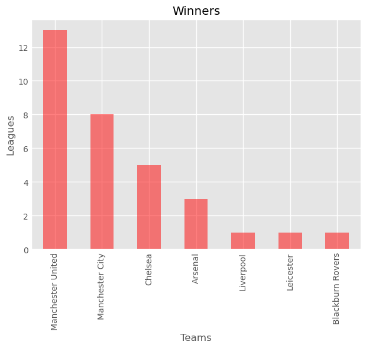

```python
winner = main[main['Rank'] == 1].Team_Name.value_counts()
p = winner.plot(kind='bar', color='r', alpha=0.5)
plt.title('Winners')
plt.xlabel('Teams')
plt.ylabel('Leagues')
```

### English Premier League Runner-Up:

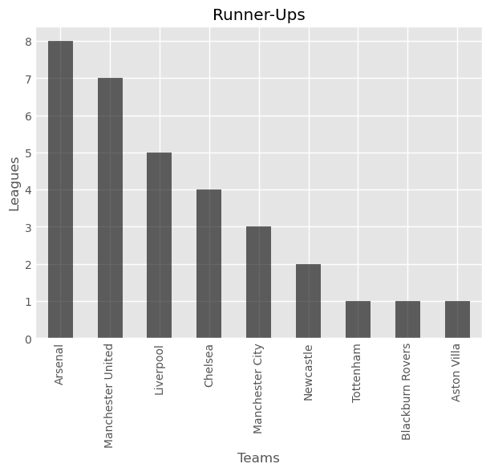

```python
runnerup = main[main['Rank'] == 2].Team_Name.value_counts()
p = runnerup.plot(kind='bar', color='black', alpha=0.6)
plt.xlabel('Teams')
plt.ylabel('Leagues')
plt.title('Runner-Ups')
```

### Who dominated the league in the early 2000s:¶

Based on our previous analysis, we obtained the precise number of games each team has won or nearly won. From the chart we generated, we identified the winning team for each season. This chart spans from 2000 to 2009, highlighting the performance peaks of each ranked team in the league. Our analysis confirms the consistent presence of Manchester United in the rankings, reflecting their enduring competitiveness. Moreover, the chart reveals a significant peak for Chelsea in the 2004-2005 season, indicating their championship victory during that period.

```python
domination = pd.get_dummies(main[main['Rank'] == 1][['Team_Name', 'season']], columns=['Team_Name'], prefix='', prefix_sep='')
domination.set_index('season', inplace=True)
domination
```

| season | Arsenal | Blackburn Rovers | Chelsea | Leicester | Liverpool | Manchester City | Manchester United |
| --- | --- | --- | --- | --- | --- | --- | --- |
| 2023-24 | False | False | False | False | False | True | False |
| 2022-23 | False | False | False | False | False | True | False |
| 2021-22 | False | False | False | False | False | True | False |
| 2020-21 | False | False | False | False | False | True | False |
| 2019-20 | False | False | False | False | True | False | False |
| 2018-19 | False | False | False | False | False | True | False |
| 2017-18 | False | False | False | False | False | True | False |
| 2016-17 | False | False | True | False | False | False | False |
| 2015-16 | False | False | False | True | False | False | False |
| 2014-15 | False | False | True | False | False | False | False |
| 2013-14 | False | False | False | False | False | True | False |
| 2012-13 | False | False | False | False | False | False | True |
| 2011-12 | False | False | False | False | False | True | False |
| 2010-11 | False | False | False | False | False | False | True |
| 2009-10 | False | False | True | False | False | False | False |
| 2008-09 | False | False | False | False | False | False | True |
| 2007-08 | False | False | False | False | False | False | True |
| 2006-07 | False | False | False | False | False | False | True |
| 2005-06 | False | False | True | False | False | False | False |
| 2004-05 | False | False | True | False | False | False | False |
| 2003-04 | True | False | False | False | False | False | False |
| 2002-03 | False | False | False | False | False | False | True |
| 2001-02 | True | False | False | False | False | False | False |
| 2000-01 | False | False | False | False | False | False | True |
| 1999-00 | False | False | False | False | False | False | True |
| 1998-99 | False | False | False | False | False | False | True |
| 1997-98 | True | False | False | False | False | False | False |
| 1996-97 | False | False | False | False | False | False | True |
| 1995-96 | False | False | False | False | False | False | True |
| 1994-95 | False | True | False | False | False | False | False |
| 1993-94 | False | False | False | False | False | False | True |
| 1992-93 | False | False | False | False | False | False | True |

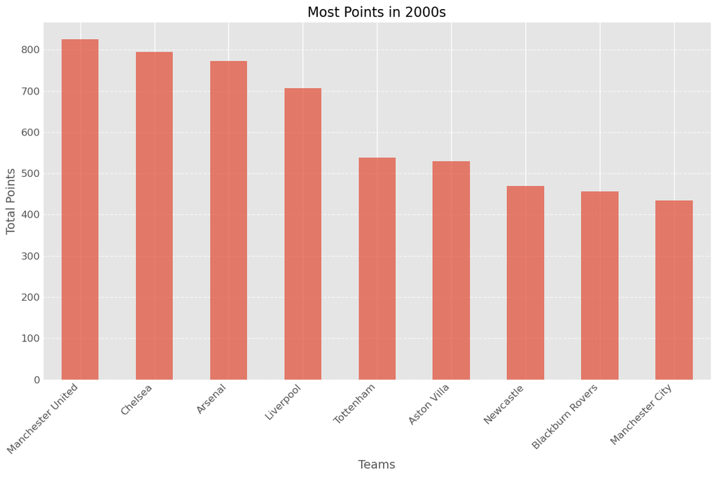

```python
year2000s = main.pivot(index='season', columns='Team_Name', values='Points')
seasons = ['2000-01', '2001-02', '2002-03', '2003-04', '2004-05', '2005-06', '2006-07', '2007-08', '2008-09', '2009-10']
teams = ['Manchester United', 'Arsenal', 'Liverpool', 'Manchester City','Chelsea', 'Newcastle', 'Tottenham', 'Blackburn Rovers', 'Aston Villa']
total = year2000s.loc[seasons, teams].sum()
plt.figure(figsize=(12, 8))
total.sort_values(ascending=False).plot(kind='bar', alpha=0.7)

plt.xticks(rotation=45, ha='right', fontsize=12)
plt.yticks(fontsize=12)
plt.xlabel('Teams', fontsize=14)
plt.ylabel('Total Points', fontsize=14)
plt.title('Most Points in 2000s', fontsize=16)
plt.grid(axis='y', linestyle='--', alpha=0.7)
plt.tight_layout()
plt.show()
```

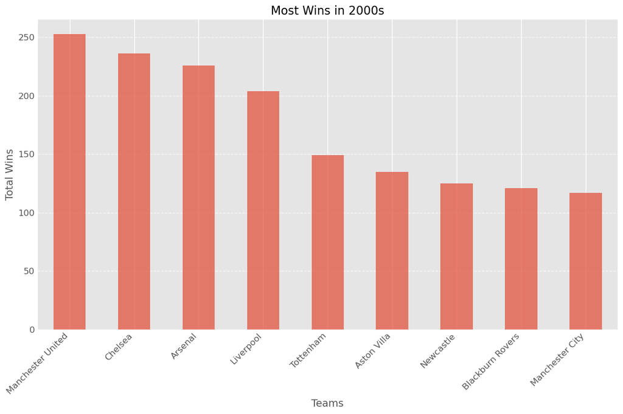

```python
year2000s = main.pivot(index='season', columns='Team_Name', values='W')
seasons = ['2000-01', '2001-02', '2002-03', '2003-04', '2004-05', '2005-06', '2006-07', '2007-08', '2008-09', '2009-10']
teams = ['Manchester United', 'Arsenal', 'Liverpool', 'Manchester City','Chelsea', 'Newcastle', 'Tottenham', 'Blackburn Rovers', 'Aston Villa']
total = year2000s.loc[seasons, teams].sum()
plt.figure(figsize=(12, 8))
total.sort_values(ascending=False).plot(kind='bar', alpha=0.7)

plt.xticks(rotation=45, ha='right', fontsize=12)
plt.yticks(fontsize=12)
plt.xlabel('Teams', fontsize=14)
plt.ylabel('Total Wins', fontsize=14)
plt.title('Most Wins in 2000s', fontsize=16)
plt.grid(axis='y', linestyle='--', alpha=0.7)
plt.tight_layout()
plt.show()
```

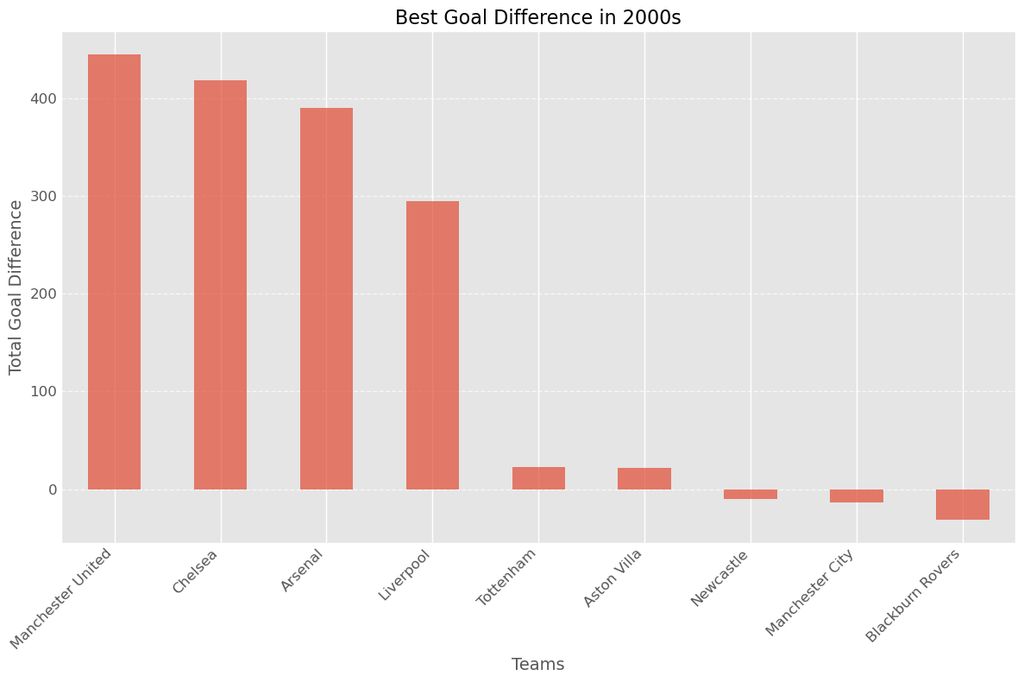

```python
year2000s = main.pivot(index='season', columns='Team_Name', values='GD')
seasons = ['2000-01', '2001-02', '2002-03', '2003-04', '2004-05', '2005-06', '2006-07', '2007-08', '2008-09', '2009-10']
teams = ['Manchester United', 'Arsenal', 'Liverpool', 'Manchester City','Chelsea', 'Newcastle', 'Tottenham', 'Blackburn Rovers', 'Aston Villa']
total = year2000s.loc[seasons, teams].sum()
plt.figure(figsize=(12, 8))
total.sort_values(ascending=False).plot(kind='bar', alpha=0.7)

plt.xticks(rotation=45, ha='right', fontsize=12)
plt.yticks(fontsize=12)
plt.xlabel('Teams', fontsize=14)
plt.ylabel('Total Goal Difference', fontsize=14)
plt.title('Best Goal Difference in 2000s', fontsize=16)
plt.grid(axis='y', linestyle='--', alpha=0.7)
plt.tight_layout()
plt.show()
```

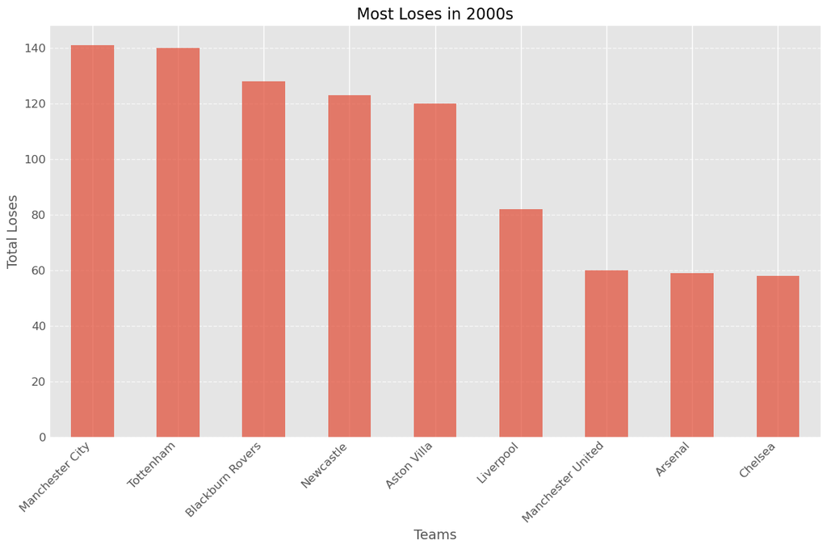

```python
year2000s = main.pivot(index='season', columns='Team_Name', values='L')
seasons = ['2000-01', '2001-02', '2002-03', '2003-04', '2004-05', '2005-06', '2006-07', '2007-08', '2008-09', '2009-10']
teams = ['Manchester United', 'Arsenal', 'Liverpool', 'Manchester City','Chelsea', 'Newcastle', 'Tottenham', 'Blackburn Rovers', 'Aston Villa']
total = year2000s.loc[seasons, teams].sum()
plt.figure(figsize=(12, 8))
total.sort_values(ascending=False).plot(kind='bar', alpha=0.7)

plt.xticks(rotation=45, ha='right', fontsize=12)
plt.yticks(fontsize=12)
plt.xlabel('Teams', fontsize=14)
plt.ylabel('Total Loses', fontsize=14)
plt.title('Most Loses in 2000s', fontsize=16)
plt.grid(axis='y', linestyle='--', alpha=0.7)
plt.tight_layout()
plt.show()
```

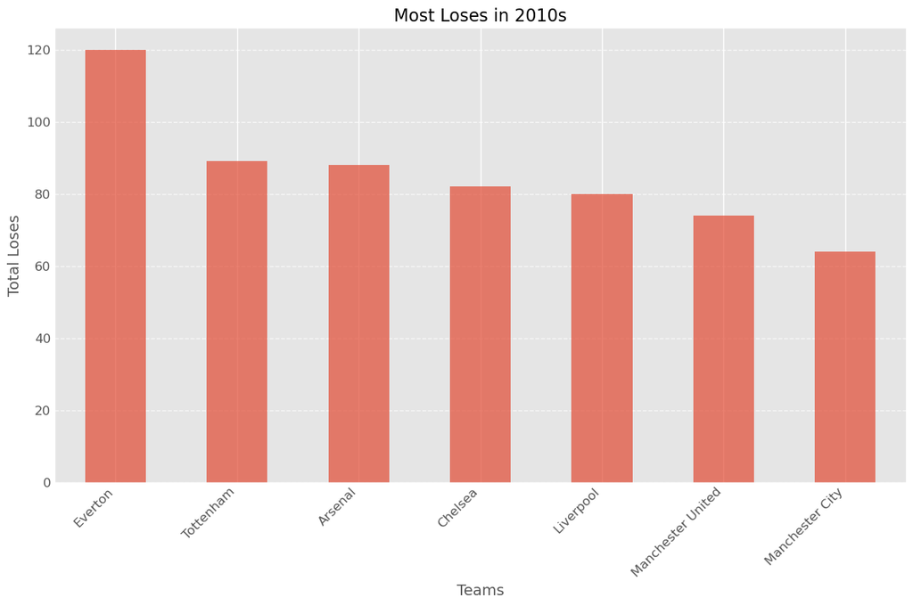

```python
year2010s = main.pivot(index='season', columns='Team_Name', values='L')
seasons = ['2010-11', '2011-12', '2012-13', '2013-14', '2014-15', '2015-16', '2016-17', '2017-18', '2018-19', '2019-20']
teams = ['Manchester United', 'Arsenal', 'Liverpool', 'Manchester City','Chelsea', 'Tottenham', 'Everton']
total = year2010s.loc[seasons, teams].sum()
plt.figure(figsize=(12, 8))
total.sort_values(ascending=False).plot(kind='bar', alpha=0.7)

plt.xticks(rotation=45, ha='right', fontsize=12)
plt.yticks(fontsize=12)
plt.xlabel('Teams', fontsize=14)
plt.ylabel('Total Loses', fontsize=14)
plt.title('Most Loses in 2010s', fontsize=16)
plt.grid(axis='y', linestyle='--', alpha=0.7)
plt.tight_layout()
plt.show()
```

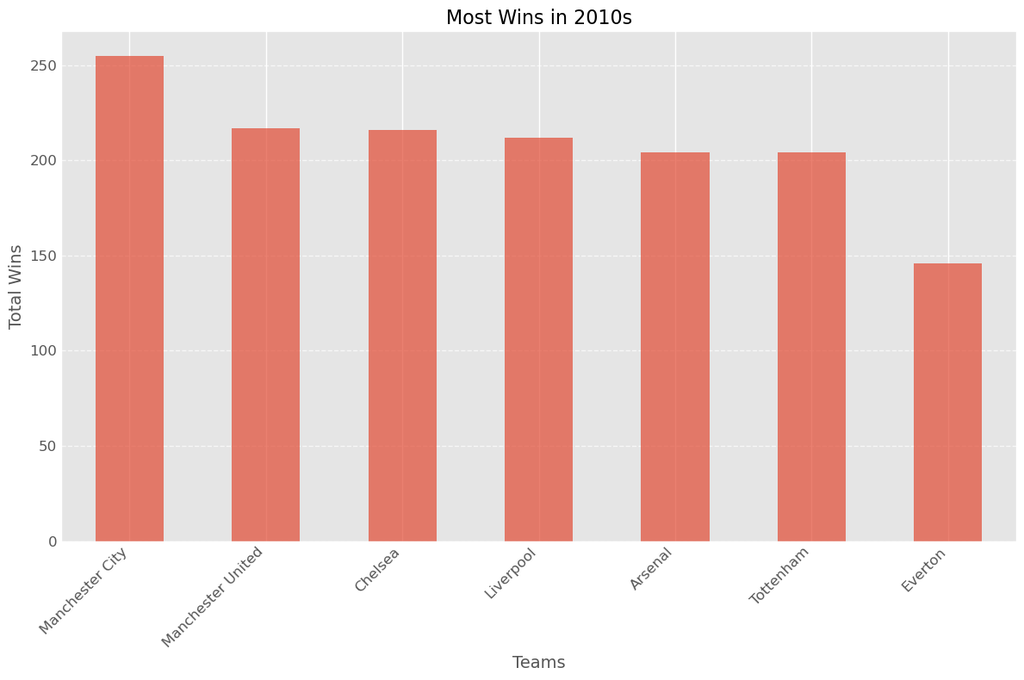

```python
year2010s = main.pivot(index='season', columns='Team_Name', values='W')
seasons = ['2010-11', '2011-12', '2012-13', '2013-14', '2014-15', '2015-16', '2016-17', '2017-18', '2018-19', '2019-20']
teams = ['Manchester United', 'Arsenal', 'Liverpool', 'Manchester City','Chelsea', 'Tottenham', 'Everton']
total = year2010s.loc[seasons, teams].sum()
plt.figure(figsize=(12, 8))
total.sort_values(ascending=False).plot(kind='bar', alpha=0.7)

plt.xticks(rotation=45, ha='right', fontsize=12)
plt.yticks(fontsize=12)
plt.xlabel('Teams', fontsize=14)
plt.ylabel('Total Wins', fontsize=14)
plt.title('Most Wins in 2010s', fontsize=16)
plt.grid(axis='y', linestyle='--', alpha=0.7)
plt.tight_layout()
plt.show()
```

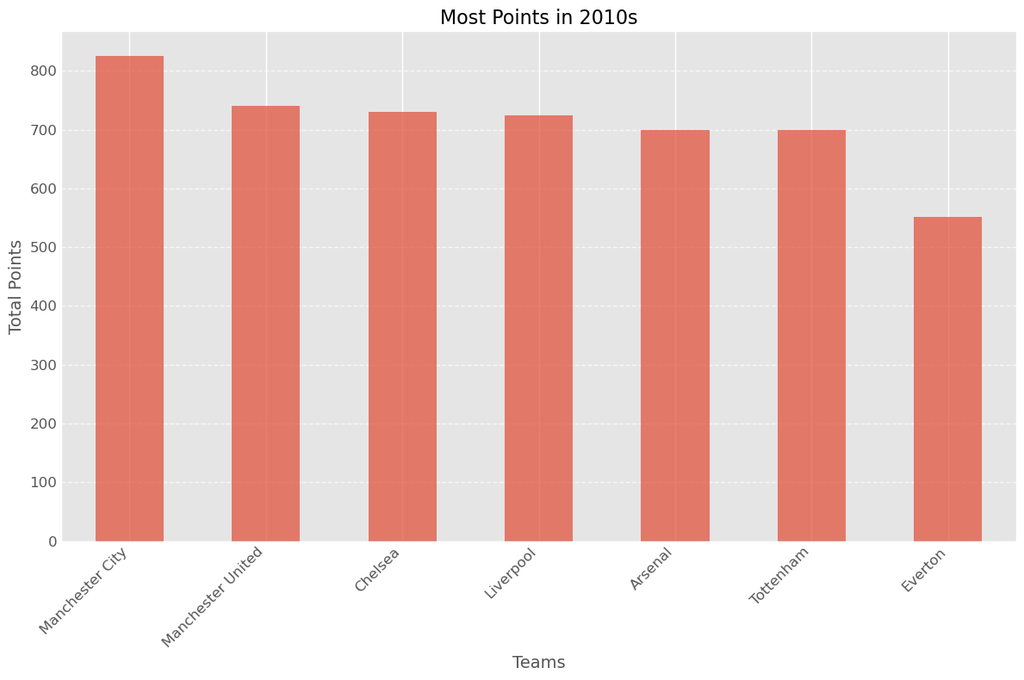

```python
year2010s = main.pivot(index='season', columns='Team_Name', values='Points')
seasons = ['2010-11', '2011-12', '2012-13', '2013-14', '2014-15', '2015-16', '2016-17', '2017-18', '2018-19', '2019-20']
teams = ['Manchester United', 'Arsenal', 'Liverpool', 'Manchester City','Chelsea', 'Tottenham', 'Everton']
total = year2010s.loc[seasons, teams].sum()
plt.figure(figsize=(12, 8))
total.sort_values(ascending=False).plot(kind='bar', alpha=0.7)

plt.xticks(rotation=45, ha='right', fontsize=12)
plt.yticks(fontsize=12)
plt.xlabel('Teams', fontsize=14)
plt.ylabel('Total Points', fontsize=14)
plt.title('Most Points in 2010s', fontsize=16)
plt.grid(axis='y', linestyle='--', alpha=0.7)
plt.tight_layout()
plt.show()
```

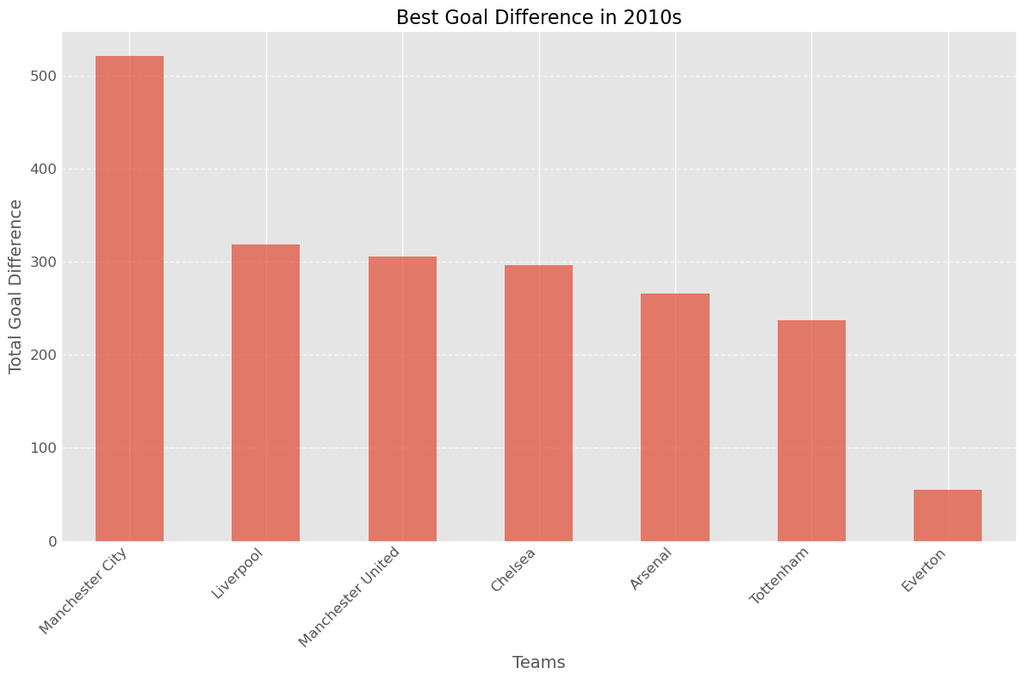

```python
year2010s = main.pivot(index='season', columns='Team_Name', values='GD')
seasons = ['2010-11', '2011-12', '2012-13', '2013-14', '2014-15', '2015-16', '2016-17', '2017-18', '2018-19', '2019-20']
teams = ['Manchester United', 'Arsenal', 'Liverpool', 'Manchester City','Chelsea', 'Tottenham', 'Everton']
total = year2010s.loc[seasons, teams].sum()
plt.figure(figsize=(12, 8))
total.sort_values(ascending=False).plot(kind='bar', alpha=0.7)

plt.xticks(rotation=45, ha='right', fontsize=12)
plt.yticks(fontsize=12)
plt.xlabel('Teams', fontsize=14)
plt.ylabel('Total Goal Difference', fontsize=14)
plt.title('Best Goal Difference in 2010s', fontsize=16)
plt.grid(axis='y', linestyle='--', alpha=0.7)
plt.tight_layout()
plt.show()
```

### Total Number of Seasons each team has been in the First Division:

Since the Premier League uses a system of promotion and relegation we wanted to see which are the teams which have had a consistent historic performance and have been in the top tier of English Football the longest. In order to do so, we produced a bar chart and arranged the data in ascending order to illustrate the duration each team has spent in the top division of the league. Liverpool and Manchester United share the top position, having spent the longest time in the First Division. Following them, Arsenal holds third place, with Chelsea in fourth.

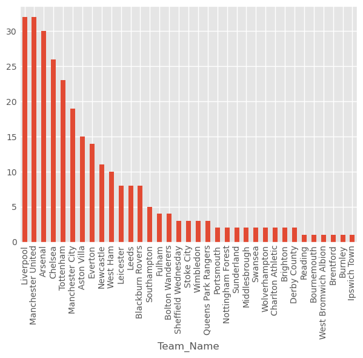

```python
main['firstDiv'] = main['Rank'].map(lambda x : 1 if (int(x)<10) else 0)
div = main.groupby('Team_Name').sum('firstDiv').firstDiv.sort_values(ascending = False)[0:35]
div.plot(kind='bar')
```

### The Number of Red Cards Per Season:

We conducted a groupby() operation on the seasons and tallied the occurrences of red cards issued each season. One prominent peak was observed between the seasons 2002-2003 and 2007-2008, during which the highest number of red cards were issued. Moreover, the inaugural season from 1993-1994 appeared to have the fewest instances of red cards handed out.

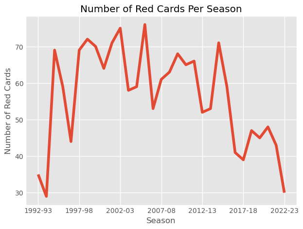

```python
foul_red = main.groupby('season').sum().RD[:-1]
foul_red.plot()
plt.title('Number of Red Cards Per Season')
plt.xlabel('Season')
plt.ylabel('Number of Red Cards')
```

### The number of Yellow Cards Per Season:

We utilized a groupby() function on the seasons once more, this time focusing on YC (yellow cards) instead of RD (red cards), enabling us to specifically examine the count of yellow cards per season. Two distinct peaks were evident: one spanning from the seasons 1997-1998 to 2002-2003, and another from the seasons 2012-2013 to 2017-2018, during which the highest numbers of yellow cards were recorded.

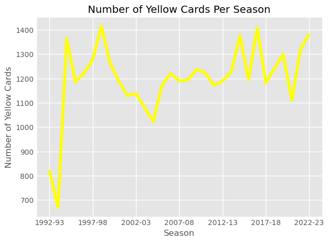

```python
foul_yellow = main.groupby('season').sum().YC[:-1]
foul_yellow.plot(color='yellow')
plt.title('Number of Yellow Cards Per Season')
plt.xlabel('Season')
plt.ylabel('Number of Yellow Cards')
```

### The average number of Red Cards per Team:

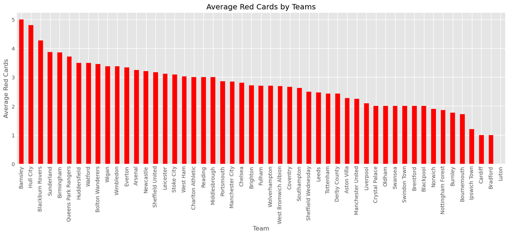

```python
avg_r = main.groupby('Team_Name').RD.mean().sort_values(ascending=False)
avg_r.plot(kind='bar', color='red', figsize=(15,5))
plt.title('Average Red Cards by Teams')
plt.xlabel('Team')
plt.ylabel('Average Red Cards')
```

### The Average Number of Yellow Cards Per Team:

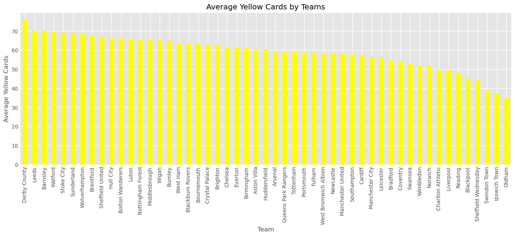

```python
avg_y = main.groupby('Team_Name').YC.mean().sort_values(ascending=False)
avg_y.plot(kind='bar', color='yellow', figsize=(15,5))
plt.title('Average Yellow Cards by Teams')
plt.xlabel('Team')
plt.ylabel('Average Yellow Cards')
```

### Fairplay:

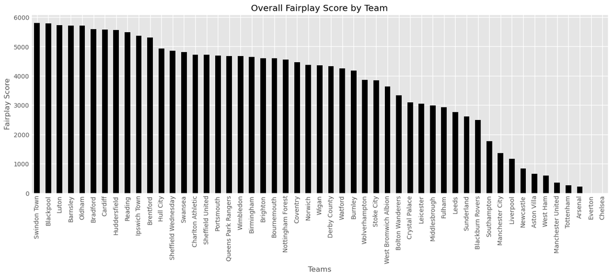

```python
unfair = (main.groupby('Team_Name').sum().YC) + 2*(main.groupby('Team_Name').sum().YC)
highest = unfair.max()
fp = unfair.apply(lambda x : highest-x ).sort_values(ascending = False).rename("fp")
fp.plot(kind='bar', color='black', figsize=(15,5))
plt.title('Overall Fairplay Score by Team')
plt.xlabel('Teams')
plt.ylabel('Fairplay Score')
```

### Regression

To test our hypothesis that the number of times a league is in the first divison is linearly related to the team's average Goal difference and it's Fairplay, we first created a table for the teams' avg GD (Goal Difference)

We then created a multiple linear regression with Number of times in the First division as the response variable and the the GD and Fairplay score as our explanatory variables.

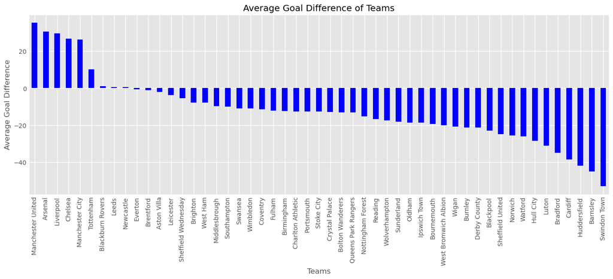

```python
goalD = main.groupby('Team_Name').GD.mean().sort_values(ascending=False)
goalD.plot(kind='bar', color='blue', figsize=(15,5))
plt.title('Average Goal Difference of Teams')
plt.xlabel('Teams')
plt.ylabel('Average Goal Difference')
```

```python
dataF=pd.concat([div,fp,goalD],axis=1).dropna()
dataF
X = dataF[['fp', 'GD']]
y = dataF['firstDiv']
linear = linear_model.LinearRegression()
res = linear.fit(X, y)
print('Intercept:', res.intercept_)
print('Coefficients:', res.coef_)
dataF
```

```
Intercept: 15.045873284061788
Coefficients: [-0.00165259  0.43520089]
```

| Team_Name | firstDiv | fp | GD |
| --- | --- | --- | --- |
| Liverpool | 32.0 | 1176 | 29.531250 |
| Manchester United | 32.0 | 351 | 35.343750 |
| Arsenal | 30.0 | 222 | 30.468750 |
| Chelsea | 26.0 | 0 | 26.625000 |
| Tottenham | 23.0 | 261 | 10.125000 |
| Manchester City | 19.0 | 1359 | 26.333333 |
| Aston Villa | 15.0 | 657 | -2.172414 |
| Everton | 14.0 | 3 | -0.718750 |
| Newcastle | 11.0 | 837 | 0.551724 |
| West Ham | 10.0 | 594 | -7.821429 |
| Leicester | 8.0 | 3054 | -3.823529 |
| Leeds | 8.0 | 2766 | 0.600000 |
| Blackburn Rovers | 8.0 | 2499 | 1.111111 |
| Southampton | 5.0 | 1764 | -10.041667 |
| Fulham | 4.0 | 2928 | -12.117647 |
| Bolton Wanderers | 4.0 | 3342 | -13.076923 |
| Sheffield Wednesday | 3.0 | 4863 | -5.500000 |
| Stoke City | 3.0 | 3849 | -12.700000 |
| Wimbledon | 3.0 | 4671 | -11.000000 |
| Queens Park Rangers | 3.0 | 4680 | -13.142857 |
| Portsmouth | 2.0 | 4689 | -12.571429 |
| Nottingham Forest | 2.0 | 4551 | -15.285714 |
| Sunderland | 2.0 | 2610 | -18.250000 |
| Middlesbrough | 2.0 | 2985 | -9.733333 |
| Swansea | 2.0 | 4809 | -11.000000 |
| Wolverhampton | 2.0 | 3864 | -17.400000 |
| Charlton Athletic | 2.0 | 4725 | -12.500000 |
| Brighton | 2.0 | 4602 | -7.714286 |
| Derby County | 2.0 | 4326 | -21.285714 |
| Reading | 1.0 | 5493 | -16.666667 |
| Bournemouth | 1.0 | 4596 | -19.285714 |
| West Bromwich Albion | 1.0 | 3642 | -20.153846 |
| Brentford | 1.0 | 5310 | -1.000000 |
| Burnley | 1.0 | 4173 | -21.222222 |
| Ipswich Town | 1.0 | 5367 | -18.600000 |

Let’s break down what each of these numbers means:

Intercept Value: The intercept represents the estimated average value of our dependent variable when all independent variables are zero. In our case, this indicates that if a team has a fairplay score of 0 and a goal difference of 0, they are expected to be in the first division about 15 times.

Coefficients: We have two coefficients for the Fairplay and Goal Difference (GD) variables. These coefficients indicate the relationship between each independent variable and the dependent variable. Specifically:

A 1-unit increase in the Fairplay score is associated with an approximate decrease of 0.002 in the average number of times a team is in the first division.

A 1-unit increase in the Goal Difference score is associated with an approximate increase of 0.43 in the average number of times a team is in the first division.

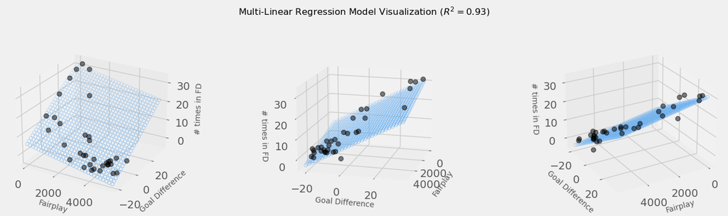

```python
X = dataF[['fp', 'GD']].values.reshape(-1,2)
Y = dataF['firstDiv']
x = X[:, 0]
y = X[:, 1]
z = Y
xx_pred = np.linspace(dataF['fp'].min(), dataF['fp'].max(), 30)
yy_pred = np.linspace(dataF['GD'].min(), dataF['GD'].max(), 30)
xx_pred, yy_pred = np.meshgrid(xx_pred, yy_pred)
model_viz = np.array([xx_pred.flatten(), yy_pred.flatten()]).T
predicted = res.predict(model_viz)
r2 = res.score(X, Y)
plt.style.use('fivethirtyeight')
fig = plt.figure(figsize=(16, 4))
ax1 = fig.add_subplot(131, projection='3d')
ax2 = fig.add_subplot(132, projection='3d')
ax3 = fig.add_subplot(133, projection='3d')
axes = [ax1, ax2, ax3]
for ax in axes:
    ax.plot(x, y, z, color='k', zorder=15, linestyle='none', marker='o', alpha=0.5)
    ax.scatter(xx_pred.flatten(), yy_pred.flatten(), predicted, facecolor=(0,0,0,0), s=20, edgecolor='#70b3f0')
    ax.set_xlabel('Fairplay', fontsize=10)
    ax.set_ylabel('Goal Difference', fontsize=10)
    ax.set_zlabel('# times in FD', fontsize=10)
    ax.locator_params(nbins=4, axis='x')
    ax.locator_params(nbins=5, axis='x')

ax1.view_init(elev=25, azim=-60)
ax2.view_init(elev=15, azim=15)
ax3.view_init(elev=25, azim=60)
fig.suptitle('Multi-Linear Regression Model Visualization ($R^2 = %.2f$)' % r2, fontsize=12, color='k')
fig.tight_layout()
```

```python
import statsmodels.api as sm
X = dataF[['fp', 'GD']]
X = sm.add_constant(X)
olsmod = sm.OLS(dataF['firstDiv'], X).fit()
print(olsmod.summary())
```

```
                            OLS Regression Results
==============================================================================
Dep. Variable:               firstDiv   R-squared:                       0.932
Model:                            OLS   Adj. R-squared:                  0.928
Method:                 Least Squares   F-statistic:                     219.8
Date:                Sat, 18 May 2024   Prob (F-statistic):           2.02e-19
Time:                        23:48:18   Log-Likelihood:                -81.396
No. Observations:                  35   AIC:                             168.8
Df Residuals:                      32   BIC:                             173.5
Df Model:                           2
Covariance Type:            nonrobust
==============================================================================
                 coef    std err          t      P>|t|      [0.025      0.975]
------------------------------------------------------------------------------
const         15.0459      1.032     14.585      0.000      12.945      17.147
fp            -0.0017      0.000     -4.748      0.000      -0.002      -0.001
GD             0.4352      0.040     10.966      0.000       0.354       0.516
==============================================================================
Omnibus:                        0.121   Durbin-Watson:                   1.698
Prob(Omnibus):                  0.941   Jarque-Bera (JB):                0.039
Skew:                          -0.057   Prob(JB):                        0.981
Kurtosis:                       2.884   Cond. No.                     8.27e+03
==============================================================================

Notes:
[1] Standard Errors assume that the covariance matrix of the errors is correctly specified.
[2] The condition number is large, 8.27e+03. This might indicate that there are
strong multicollinearity or other numerical problems.
```

Before we proceed, let's rebuild our model using the statsmodels library with the OLS() function. Then, we'll print the model summary using the summary() function on the model. This summary will contain numerous important values that we can utilize to evaluate our model.

```python
print('R2 score:', olsmod.rsquared)
```

```
R2 score: 0.9321456085127158
```

```python
print('F-statistic:', olsmod.fvalue)
print('Probability of observing value at least as high as F-statistic:', olsmod.f_pvalue)
```

```
F-statistic: 219.7990345105133
Probability of observing value at least as high as F-statistic: 2.0195162966576774e-19
```

With an f_pvalue below 0.05, we can infer that our model outperforms simpler alternatives.

```python
print(olsmod.pvalues)
```

```
const    1.090897e-15
fp       4.129980e-05
GD       2.266280e-12
dtype: float64
```

The p-values for both of our independent variables, Fairplay Score and Goal Difference, are below 0.05. This indicates that there is significant evidence to suggest that both Fairplay Score and Goal Difference have an impact on the frequency of a team being in the first division.